# Document prepared for Cesar and Trevor regarding CMIP5 data processing

Huanyuan

15/02/2020

## Output

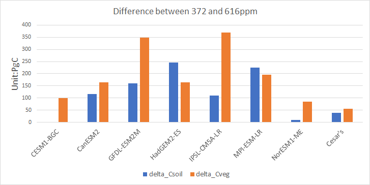

## Download data

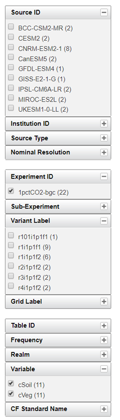

CMIP6

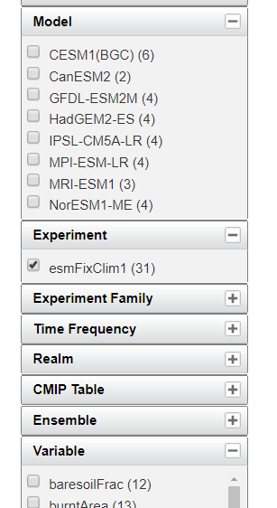

CMIP5

## Calculate global sum

Every model is different from each other in resolution…

|  | lon | lat | unit |  |
| --- | --- | --- | --- | --- |
| CESM1-BGC | 288 | 192 | kg/m2 |  |
| CanESM2 | 128 | 64 | kg/m2 |  |
| GFDL-ESM2M | 144 | 90 | kg/m2 |  |
| HadGEM2-ES | 192 | 145 | kg/m2 |  |
| IPSL-CM5A-LR | 96 | 96 | kg/m2 |  |
| MPI-ESM-LR | 192 | 96 | kg/m2 |  |
| NorESM1-ME | 144 | 96 | kg/m2 |  |

This is done by running **CMIP5.m**, which do unit conversion and grid size calculation. Then, I copied yearly output into **For_CESAR.csv**

## Calculate delta Cveg and Csoil

Some of the model started from 1850, some from 1860, some from 0001, so I tried to calculate their CO2 output, however, only four models reported CO2 concentration under experiment esmFixClim1. This is done with **CMIP5_co2.m**, However, I found that GFDL-ESM2M did not increase by 1% per year, it increased too slowly, and CO2 concentration in CESM1-BGC is even decreasing whatever, lets assume first year is 285ppm, so 372ppm should be year 28. amd 616ppm should be year 78 (well, if they do increase by 1% every year )

The use **DIfference_b_372_616.m** to compute the difference between year 78 and year 28